# Hidden vs Visible Resources in the Survival Game (Survival Analyses)

Scott Claessens

2019-12-12

# 0. Setup

You’ll need to download [Stan](http://mc-stan.org/) to your machine for these analyses. Note: this document will save **brms** model fits into your working directory.

First, let’s load all the packages we’ll need.

```r
library(brms)
library(cowplot)
library(ggplot2)
library(grid)
library(png)
library(tidyverse)
```

# 1. Study 1

Load the data from Study 1.

```r
d <-
  read.csv('data/exp1data.csv', header = TRUE) %>%
  as_tibble()
```

## 1.1. Compare conditions

```r
# survival analysis
# one participant per row so do not need the ID random effect
b4.1 <- brm(rounds_survived | cens(censored) ~ 0 + intercept + Condition + (1 | Group),
            data = d.trim, family = weibull, inits = "0",
            prior = prior(normal(0, 2), class = b, coef = "Condition"),
            iter = 2000, warmup = 1000, chains = 4, cores = 4,
            sample_prior = TRUE, seed = 2113)

save(file = "models/survival_brmsfit1.rda", b4.1)
```

```r
print(b4.1)
```

```
##  Family: weibull
##   Links: mu = log; shape = identity
## Formula: rounds_survived | cens(censored) ~ 0 + intercept + Condition + (1 | Group)
##    Data: d.trim (Number of observations: 82)
## Samples: 4 chains, each with iter = 2000; warmup = 1000; thin = 1;
##          total post-warmup samples = 4000
##
## Group-Level Effects:
## ~Group (Number of levels: 41)
##               Estimate Est.Error l-95% CI u-95% CI Rhat Bulk_ESS Tail_ESS
## sd(Intercept)     1.06      0.29     0.57     1.71 1.00     1270     2141
##
## Population-Level Effects:
##           Estimate Est.Error l-95% CI u-95% CI Rhat Bulk_ESS Tail_ESS
## intercept     3.63      0.35     3.04     4.41 1.00     1921     1670
## Condition     0.57      0.44    -0.28     1.48 1.00     2010     2160
##
## Family Specific Parameters:
##       Estimate Est.Error l-95% CI u-95% CI Rhat Bulk_ESS Tail_ESS
## shape     1.67      0.34     1.08     2.40 1.00     2395     2751
##
## Samples were drawn using sampling(NUTS). For each parameter, Eff.Sample
## is a crude measure of effective sample size, and Rhat is the potential
## scale reduction factor on split chains (at convergence, Rhat = 1).
```

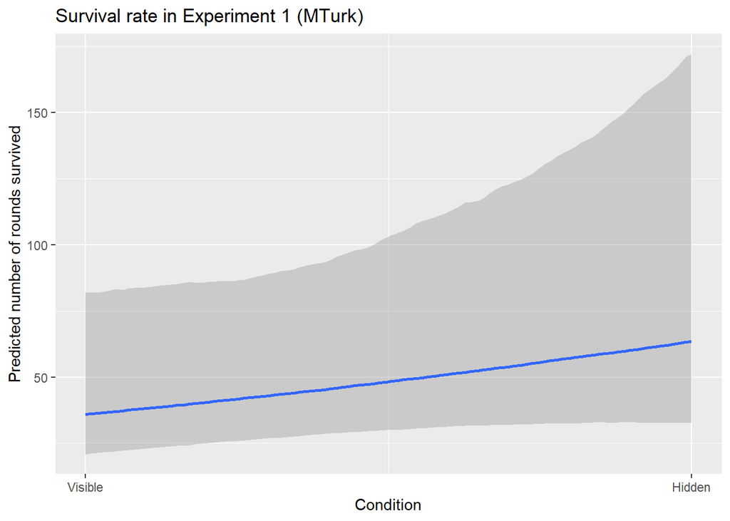

Estimate survival rate in the Visible condition.

```r
post <- posterior_samples(b4.1)

set.seed(2113)
srateVisible <- rweibull(4000, post$shape, exp(post$b_intercept))
median(srateVisible)
```

```
## [1] 28.1571
```

Estimate survival rate in the Hidden condition.

```r
set.seed(2113)
srateHidden <- rweibull(4000, post$shape, exp(post$b_intercept + post$b_Condition))
median(srateHidden)
```

```
## [1] 49.50944
```

Difference between these.

```r
difference <- srateHidden - srateVisible
quantile(difference, c(0.025, 0.5, 0.975)) %>% round(2)
```

```
##   2.5%    50%  97.5%
##  -9.87  17.86 142.14
```

Does survival rate differ across conditions? Get Bayes factor.

```r
(1 / hypothesis(b4.1, "Condition = 0")$hypothesis$Evid.Ratio) %>% round(2)
```

```
## [1] 0.47
```

The Bayes factor suggests that there is more support for the null hypothesis (that survival rate is equal across conditions).

## 1.2. Proportion of rule 1 cheating

```r
b4.2 <- brm(rounds_survived | cens(censored) ~ 0 + intercept + prop_rule1 + (1 | Group),
            data = d.trim, family = weibull, inits = "0",
            prior = prior(normal(0, 2), class = b, coef = "prop_rule1"),
            iter = 2000, warmup = 1000, chains = 4, cores = 4,
            sample_prior = TRUE, seed = 2113)

save(file = "models/survival_brmsfit2.rda", b4.2)
```

```r
print(b4.2)
```

```
##  Family: weibull
##   Links: mu = log; shape = identity
## Formula: rounds_survived | cens(censored) ~ 0 + intercept + prop_rule1 + (1 | Group)
##    Data: d.trim (Number of observations: 80)
## Samples: 4 chains, each with iter = 2000; warmup = 1000; thin = 1;
##          total post-warmup samples = 4000
##
## Group-Level Effects:
## ~Group (Number of levels: 41)
##               Estimate Est.Error l-95% CI u-95% CI Rhat Bulk_ESS Tail_ESS
## sd(Intercept)     1.10      0.28     0.68     1.75 1.00     1494     1946
##
## Population-Level Effects:
##            Estimate Est.Error l-95% CI u-95% CI Rhat Bulk_ESS Tail_ESS
## intercept      3.98      0.31     3.49     4.70 1.00     1807     1857
## prop_rule1    -0.87      0.50    -1.90     0.11 1.00     2711     2648
##
## Family Specific Parameters:
##       Estimate Est.Error l-95% CI u-95% CI Rhat Bulk_ESS Tail_ESS
## shape     2.35      0.51     1.47     3.43 1.00     1460     2190
##
## Samples were drawn using sampling(NUTS). For each parameter, Eff.Sample
## is a crude measure of effective sample size, and Rhat is the potential
## scale reduction factor on split chains (at convergence, Rhat = 1).
```

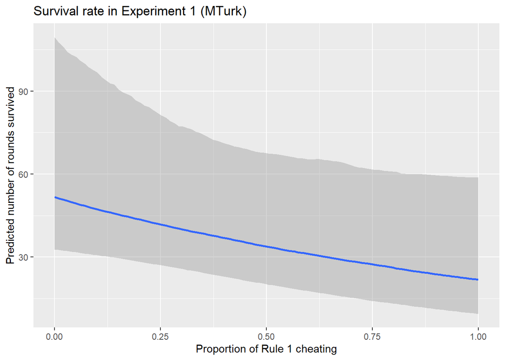

Does survival rate differ the more people cheat rule 1? Get Bayes factor.

```r
(1 / hypothesis(b4.2, "prop_rule1 = 0")$hypothesis$Evid.Ratio) %>% round(2)
```

```
## [1] 1.22
```

There is only anecdotal evidence that it does.

```r
b4.3 <- brm(rounds_survived | cens(censored) ~ 0 + intercept + prop_rule2 + (1 | Group),
            data = d.trim, family = weibull, inits = "0",
            prior = prior(normal(0, 2), class = b, coef = "prop_rule2"),
            iter = 4000, warmup = 2000, chains = 4, cores = 4,
            control = list(adapt_delta = 0.99),
            sample_prior = TRUE, seed = 2113)

save(file = "models/survival_brmsfit3.rda", b4.3)
```

```r
print(b4.3)
```

```
##  Family: weibull
##   Links: mu = log; shape = identity
## Formula: rounds_survived | cens(censored) ~ 0 + intercept + prop_rule2 + (1 | Group)
##    Data: d.trim (Number of observations: 61)
## Samples: 4 chains, each with iter = 4000; warmup = 2000; thin = 1;
##          total post-warmup samples = 8000
##
## Group-Level Effects:
## ~Group (Number of levels: 40)
##               Estimate Est.Error l-95% CI u-95% CI Rhat Bulk_ESS Tail_ESS
## sd(Intercept)     1.35      0.47     0.57     2.44 1.00     1391     1689
##
## Population-Level Effects:
##            Estimate Est.Error l-95% CI u-95% CI Rhat Bulk_ESS Tail_ESS
## intercept      4.05      0.53     3.25     5.33 1.00     3744     4166
## prop_rule2     0.49      0.57    -0.62     1.65 1.00     4390     5098
##
## Family Specific Parameters:
##       Estimate Est.Error l-95% CI u-95% CI Rhat Bulk_ESS Tail_ESS
## shape     2.37      0.89     1.02     4.45 1.00     1404     2908
##
## Samples were drawn using sampling(NUTS). For each parameter, Eff.Sample
## is a crude measure of effective sample size, and Rhat is the potential
## scale reduction factor on split chains (at convergence, Rhat = 1).
```

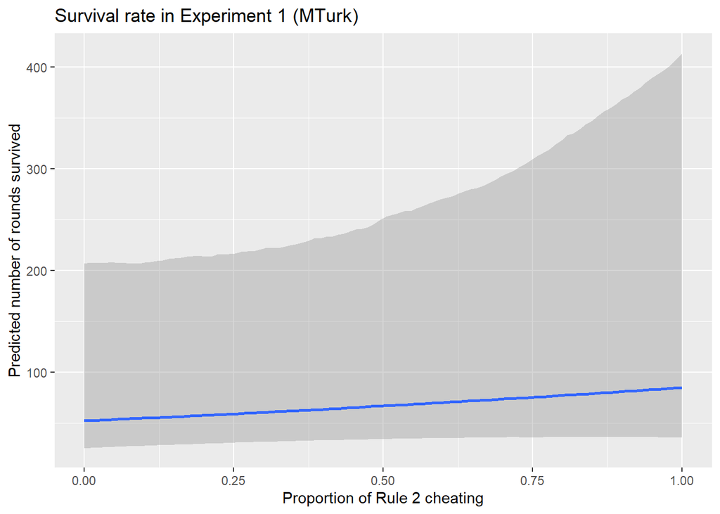

Does survival rate differ the more people cheat rule 2? Get Bayes factor.

```r
(1 / hypothesis(b4.3, "prop_rule2 = 0")$hypothesis$Evid.Ratio) %>% round(2)
```

```
## [1] 0.4
```

No. There is more evidence for the null hypothesis that the survival rate does not differ the more people cheat rule 2.

# 2. Study 2

Load the data from Study 2.

```r
d <-
    read.csv('data/exp2data.csv', header = TRUE) %>%
    as_tibble()
```

## 2.1. Compare conditions

```r
b4.4 <- brm(rounds_survived | cens(censored) ~ 0 + intercept + Condition + (1 | Group/ID),
            data = d.trim, family = weibull, inits = "0",
            prior = prior(normal(0, 2), class = b, coef = "Condition"),
            iter = 2000, warmup = 1000, chains = 4, cores = 4,
            control = list(adapt_delta = 0.9, max_treedepth = 15),
            sample_prior = TRUE, seed = 2113)

save(file = "models/survival_brmsfit4.rda", b4.4)
```

```r
print(b4.4)
```

```
##  Family: weibull
##   Links: mu = log; shape = identity
## Formula: rounds_survived | cens(censored) ~ 0 + intercept + Condition + (1 | Group/ID)
##    Data: d.trim (Number of observations: 160)
## Samples: 4 chains, each with iter = 2000; warmup = 1000; thin = 1;
##          total post-warmup samples = 4000
##
## Group-Level Effects:
## ~Group (Number of levels: 40)
##               Estimate Est.Error l-95% CI u-95% CI Rhat Bulk_ESS Tail_ESS
## sd(Intercept)     0.41      0.24     0.03     0.91 1.01      998     1660
##
## ~Group:ID (Number of levels: 80)
##               Estimate Est.Error l-95% CI u-95% CI Rhat Bulk_ESS Tail_ESS
## sd(Intercept)     0.27      0.20     0.01     0.74 1.00     1473     1978
##
## Population-Level Effects:
##           Estimate Est.Error l-95% CI u-95% CI Rhat Bulk_ESS Tail_ESS
## intercept     4.63      0.34     4.07     5.41 1.00     2588     1821
## Condition    -0.82      0.29    -1.45    -0.29 1.00     4107     2307
##
## Family Specific Parameters:
##       Estimate Est.Error l-95% CI u-95% CI Rhat Bulk_ESS Tail_ESS
## shape     1.06      0.14     0.80     1.34 1.00     3168     2848
##
## Samples were drawn using sampling(NUTS). For each parameter, Eff.Sample
## is a crude measure of effective sample size, and Rhat is the potential
## scale reduction factor on split chains (at convergence, Rhat = 1).
```

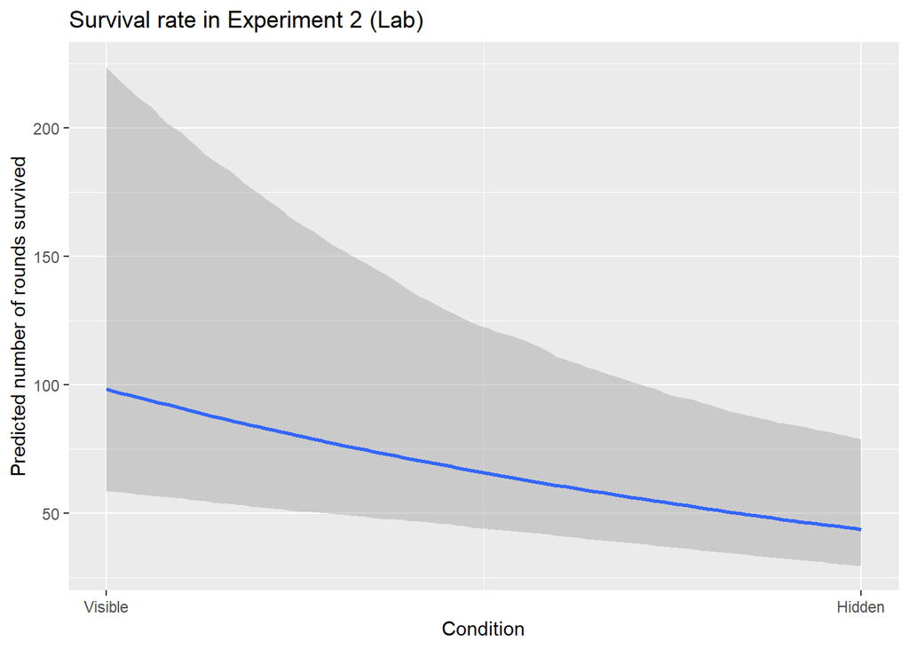

Estimate survival rate in Visible condition.

```r
post <- posterior_samples(b4.4)

set.seed(2113)
srateVisible <- rweibull(4000, post$shape, exp(post$b_intercept))
median(srateVisible)
```

```
## [1] 68.16804
```

Estimate survival rate in Hidden condition.

```r
set.seed(2113)
srateHidden <- rweibull(4000, post$shape, exp(post$b_intercept + post$b_Condition))
median(srateHidden)
```

```
## [1] 30.30035
```

```r
difference <- srateHidden - srateVisible
quantile(difference, c(0.025, 0.5, 0.975))
```

```
##        2.5%         50%       97.5%
## -282.519454  -34.224813   -1.160185
```

Does survival rate differ across conditions? Get Bayes factor.

```r
(1 / hypothesis(b4.4, "Condition = 0")$hypothesis$Evid.Ratio) %>% round(2)
```

```
## [1] 14.67
```

Yes, it does.

## 2.2. Proportion of rule 1 cheating

```r
b4.5 <- brm(rounds_survived | cens(censored) ~ 0 + intercept + prop_rule1 + (1 | Group/ID),
            data = d.trim, family = weibull, inits = "0",
            prior = prior(normal(0, 2), class = b, coef = "prop_rule1"),
            iter = 2000, warmup = 1000, chains = 4, cores = 4,
            control = list(adapt_delta = 0.99),
            sample_prior = TRUE, seed = 2113)

save(file = "models/survival_brmsfit5.rda", b4.5)
```

```r
print(b4.5)
```

```
##  Family: weibull
##   Links: mu = log; shape = identity
## Formula: rounds_survived | cens(censored) ~ 0 + intercept + prop_rule1 + (1 | Group/ID)
##    Data: d.trim (Number of observations: 154)
## Samples: 4 chains, each with iter = 2000; warmup = 1000; thin = 1;
##          total post-warmup samples = 4000
##
## Group-Level Effects:
## ~Group (Number of levels: 40)
##               Estimate Est.Error l-95% CI u-95% CI Rhat Bulk_ESS Tail_ESS
## sd(Intercept)     0.28      0.20     0.01     0.76 1.00     1846     2709
##
## ~Group:ID (Number of levels: 80)
##               Estimate Est.Error l-95% CI u-95% CI Rhat Bulk_ESS Tail_ESS
## sd(Intercept)     0.23      0.17     0.01     0.62 1.00     2160     2079
##
## Population-Level Effects:
##            Estimate Est.Error l-95% CI u-95% CI Rhat Bulk_ESS Tail_ESS
## intercept      4.09      0.26     3.67     4.67 1.00     4875     2616
## prop_rule1     0.50      0.58    -0.56     1.71 1.00     6835     2590
##
## Family Specific Parameters:
##       Estimate Est.Error l-95% CI u-95% CI Rhat Bulk_ESS Tail_ESS
## shape     1.13      0.16     0.83     1.46 1.00     4751     2750
##
## Samples were drawn using sampling(NUTS). For each parameter, Eff.Sample
## is a crude measure of effective sample size, and Rhat is the potential
## scale reduction factor on split chains (at convergence, Rhat = 1).
```

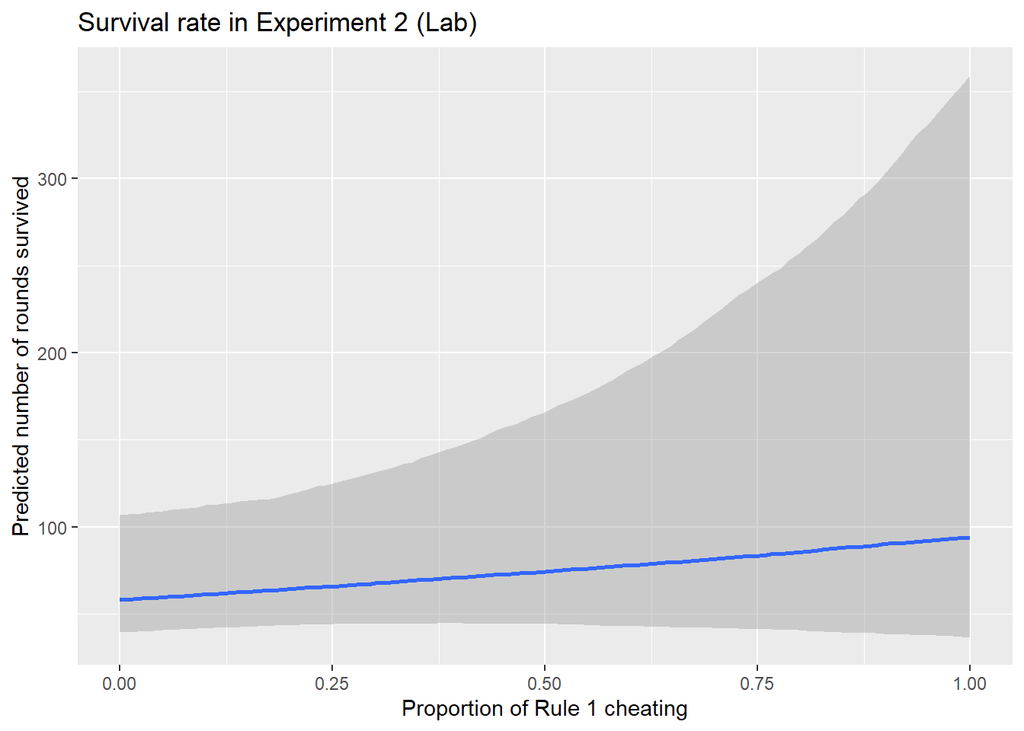

Does survival rate differ the more people cheat rule 1? Get Bayes factor.

```r
(1 / hypothesis(b4.5, "prop_rule1 = 0")$hypothesis$Evid.Ratio) %>% round(2)
```

```
## [1] 0.41
```

No. There is more evidence for the null hypothesis that the survival rate does not differ the more people break rule 1.

## 2.3. Proportion of rule 2 cheating

```r
b4.6 <- brm(rounds_survived | cens(censored) ~ 0 + intercept + prop_rule2 + (1 | Group/ID),
            data = d.trim, family = weibull, inits = "0",
            prior = prior(normal(0, 2), class = b, coef = "prop_rule2"),
            iter = 2000, warmup = 1000, chains = 4, cores = 4,
            control = list(adapt_delta = 0.99),
            sample_prior = TRUE, seed = 2113)

save(file = "models/survival_brmsfit6.rda", b4.6)
```

```r
print(b4.6)
```

```
##  Family: weibull
##   Links: mu = log; shape = identity
## Formula: rounds_survived | cens(censored) ~ 0 + intercept + prop_rule2 + (1 | Group/ID)
##    Data: d.trim (Number of observations: 117)
## Samples: 4 chains, each with iter = 2000; warmup = 1000; thin = 1;
##          total post-warmup samples = 4000
##
## Group-Level Effects:
## ~Group (Number of levels: 40)
##               Estimate Est.Error l-95% CI u-95% CI Rhat Bulk_ESS Tail_ESS
## sd(Intercept)     0.29      0.21     0.01     0.81 1.00     1607     2171
##
## ~Group:ID (Number of levels: 73)
##               Estimate Est.Error l-95% CI u-95% CI Rhat Bulk_ESS Tail_ESS
## sd(Intercept)     0.28      0.21     0.01     0.78 1.00     1392     1545
##
## Population-Level Effects:
##            Estimate Est.Error l-95% CI u-95% CI Rhat Bulk_ESS Tail_ESS
## intercept      4.26      0.35     3.71     5.10 1.00     3088     1700
## prop_rule2    -0.17      0.42    -0.97     0.66 1.00     4386     2711
##
## Family Specific Parameters:
##       Estimate Est.Error l-95% CI u-95% CI Rhat Bulk_ESS Tail_ESS
## shape     1.39      0.25     0.94     1.90 1.00     4404     2483
##
## Samples were drawn using sampling(NUTS). For each parameter, Eff.Sample
## is a crude measure of effective sample size, and Rhat is the potential
## scale reduction factor on split chains (at convergence, Rhat = 1).
```

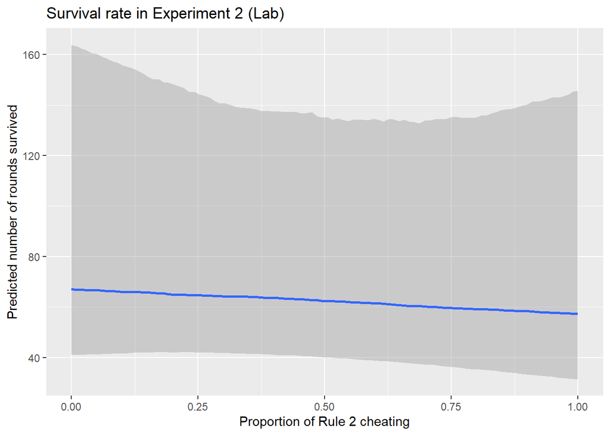

Does survival rate differ the more people cheat rule 2? Get Bayes factor.

```r
(1 / hypothesis(b4.6, "prop_rule2 = 0")$hypothesis$Evid.Ratio) %>% round(2)
```

```
## [1] 0.2
```